# Machine Learning Hackathon

## Getting Started

In the targeted approach the company tries to identify in advance customers who are likely to churn. The company then targets those customers with special programs or incentives. This approach can bring in huge loss for a company, if churn predictions are inaccurate, because then firms are wasting incentive money on customers who would have stayed anyway. There are numerous predictive modeling techniques for predicting customer churn. These vary in terms of statistical technique (e.g., neural nets versus logistic regression versus survival analysis), and variable selection method (e.g., theory versus stepwise selection).

## Exploring the Data

```python
# Import libraries necessary for this project
import numpy as np
import pandas as pd
from time import time
from IPython.display import display # Allows the use of display() for DataFrames

# Import supplementary visualization code visuals.py
import visuals as vs

import numpy as np # linear algebra
import pandas as pd # data processing, CSV file I/O (e.g. pd.read_csv)
import seaborn as sns
import matplotlib.pyplot as plt

from subprocess import check_output
from sklearn.model_selection import train_test_split
from sklearn.linear_model import LogisticRegression
from sklearn import metrics
from sklearn.ensemble import RandomForestClassifier
from sklearn.model_selection import cross_val_score



# Pretty display for notebooks
%matplotlib inline

# Load the Census dataset
tele = pd.read_csv("bigml_telecom.csv")

# Success - Display the first record
display(tele.head(n=5))
```

|  | state | account length | area code | phone number | international plan | voice mail plan | number vmail messages | total day minutes | total day calls | total day charge | ... | total eve calls | total eve charge | total night minutes | total night calls | total night charge | total intl minutes | total intl calls | total intl charge | customer service calls | churn |
| --- | --- | --- | --- | --- | --- | --- | --- | --- | --- | --- | --- | --- | --- | --- | --- | --- | --- | --- | --- | --- | --- |
| 0 | KS | 128 | 415 | 382-4657 | no | yes | 25 | 265.1 | 110 | 45.07 | ... | 99 | 16.78 | 244.7 | 91 | 11.01 | 10.0 | 3 | 2.70 | 1 | False |
| 1 | OH | 107 | 415 | 371-7191 | no | yes | 26 | 161.6 | 123 | 27.47 | ... | 103 | 16.62 | 254.4 | 103 | 11.45 | 13.7 | 3 | 3.70 | 1 | False |
| 2 | NJ | 137 | 415 | 358-1921 | no | no | 0 | 243.4 | 114 | 41.38 | ... | 110 | 10.30 | 162.6 | 104 | 7.32 | 12.2 | 5 | 3.29 | 0 | False |
| 3 | OH | 84 | 408 | 375-9999 | yes | no | 0 | 299.4 | 71 | 50.90 | ... | 88 | 5.26 | 196.9 | 89 | 8.86 | 6.6 | 7 | 1.78 | 2 | False |
| 4 | OK | 75 | 415 | 330-6626 | yes | no | 0 | 166.7 | 113 | 28.34 | ... | 122 | 12.61 | 186.9 | 121 | 8.41 | 10.1 | 3 | 2.73 | 3 | False |

5 rows × 21 columns

### Implementation: Data Exploration

A cursory investigation of the dataset will determine how many individuals fit into either group, and will tell us about the percentage of these individuals having churn. In the code cell below, you will need to compute the following:

- The total number of records, `'n_records'`
- The number of individuals having churn.
- The number of individuals not having churn. -Percentage of individuals having churn

```python
tele.shape[0]
```

```
3333
```

```python
print(tele.dtypes)
```

```
state                      object
account length              int64
area code                   int64
phone number               object
international plan         object
voice mail plan            object
number vmail messages       int64
total day minutes         float64
total day calls             int64
total day charge          float64
total eve minutes         float64
total eve calls             int64
total eve charge          float64
total night minutes       float64
total night calls           int64
total night charge        float64
total intl minutes        float64
total intl calls            int64
total intl charge         float64
customer service calls      int64
churn                        bool
dtype: object
```

```python
#Check Missing values
tele.info()
```

```
<class 'pandas.core.frame.DataFrame'>
RangeIndex: 3333 entries, 0 to 3332
Data columns (total 21 columns):
state                     3333 non-null object
account length            3333 non-null int64
area code                 3333 non-null int64
phone number              3333 non-null object
international plan        3333 non-null object
voice mail plan           3333 non-null object
number vmail messages     3333 non-null int64
total day minutes         3333 non-null float64
total day calls           3333 non-null int64
total day charge          3333 non-null float64
total eve minutes         3333 non-null float64
total eve calls           3333 non-null int64
total eve charge          3333 non-null float64
total night minutes       3333 non-null float64
total night calls         3333 non-null int64
total night charge        3333 non-null float64
total intl minutes        3333 non-null float64
total intl calls          3333 non-null int64
total intl charge         3333 non-null float64
customer service calls    3333 non-null int64
churn                     3333 non-null bool
dtypes: bool(1), float64(8), int64(8), object(4)
memory usage: 524.1+ KB
```

```python
#Check NAN values
tele.isna().sum()
```

```
state                     0
account length            0
area code                 0
phone number              0
international plan        0
voice mail plan           0
number vmail messages     0
total day minutes         0
total day calls           0
total day charge          0
total eve minutes         0
total eve calls           0
total eve charge          0
total night minutes       0
total night calls         0
total night charge        0
total intl minutes        0
total intl calls          0
total intl charge         0
customer service calls    0
churn                     0
dtype: int64
```

```python
#print(tele.groupby('churn')['phone number'].count())
n_records = tele.shape[0]
n_churn= tele.groupby('churn')['phone number'].count()
#Since true is the second element taking secode element for percentage of churn ie n_churn[1]
greater_percent = (n_churn[1]/n_records)*100
print("The total number of customers",n_records)
print("The number of customers that didn't churn",n_churn[0])
print("The number of customers that churn",n_churn[1])
print("The percentage of customers churned",greater_percent)
```

```
The total number of customers 3333
The number of customers that didn't churn 2850
The number of customers that churn 483
The percentage of customers churned 14.491449144914492
```

```python
tele.describe()
```

|  | account length | area code | number vmail messages | total day minutes | total day calls | total day charge | total eve minutes | total eve calls | total eve charge | total night minutes | total night calls | total night charge | total intl minutes | total intl calls | total intl charge | customer service calls |
| --- | --- | --- | --- | --- | --- | --- | --- | --- | --- | --- | --- | --- | --- | --- | --- | --- |
| count | 3333.000000 | 3333.000000 | 3333.000000 | 3333.000000 | 3333.000000 | 3333.000000 | 3333.000000 | 3333.000000 | 3333.000000 | 3333.000000 | 3333.000000 | 3333.000000 | 3333.000000 | 3333.000000 | 3333.000000 | 3333.000000 |
| mean | 101.064806 | 437.182418 | 8.099010 | 179.775098 | 100.435644 | 30.562307 | 200.980348 | 100.114311 | 17.083540 | 200.872037 | 100.107711 | 9.039325 | 10.237294 | 4.479448 | 2.764581 | 1.562856 |
| std | 39.822106 | 42.371290 | 13.688365 | 54.467389 | 20.069084 | 9.259435 | 50.713844 | 19.922625 | 4.310668 | 50.573847 | 19.568609 | 2.275873 | 2.791840 | 2.461214 | 0.753773 | 1.315491 |
| min | 1.000000 | 408.000000 | 0.000000 | 0.000000 | 0.000000 | 0.000000 | 0.000000 | 0.000000 | 0.000000 | 23.200000 | 33.000000 | 1.040000 | 0.000000 | 0.000000 | 0.000000 | 0.000000 |
| 25% | 74.000000 | 408.000000 | 0.000000 | 143.700000 | 87.000000 | 24.430000 | 166.600000 | 87.000000 | 14.160000 | 167.000000 | 87.000000 | 7.520000 | 8.500000 | 3.000000 | 2.300000 | 1.000000 |
| 50% | 101.000000 | 415.000000 | 0.000000 | 179.400000 | 101.000000 | 30.500000 | 201.400000 | 100.000000 | 17.120000 | 201.200000 | 100.000000 | 9.050000 | 10.300000 | 4.000000 | 2.780000 | 1.000000 |
| 75% | 127.000000 | 510.000000 | 20.000000 | 216.400000 | 114.000000 | 36.790000 | 235.300000 | 114.000000 | 20.000000 | 235.300000 | 113.000000 | 10.590000 | 12.100000 | 6.000000 | 3.270000 | 2.000000 |
| max | 243.000000 | 510.000000 | 51.000000 | 350.800000 | 165.000000 | 59.640000 | 363.700000 | 170.000000 | 30.910000 | 395.000000 | 175.000000 | 17.770000 | 20.000000 | 20.000000 | 5.400000 | 9.000000 |

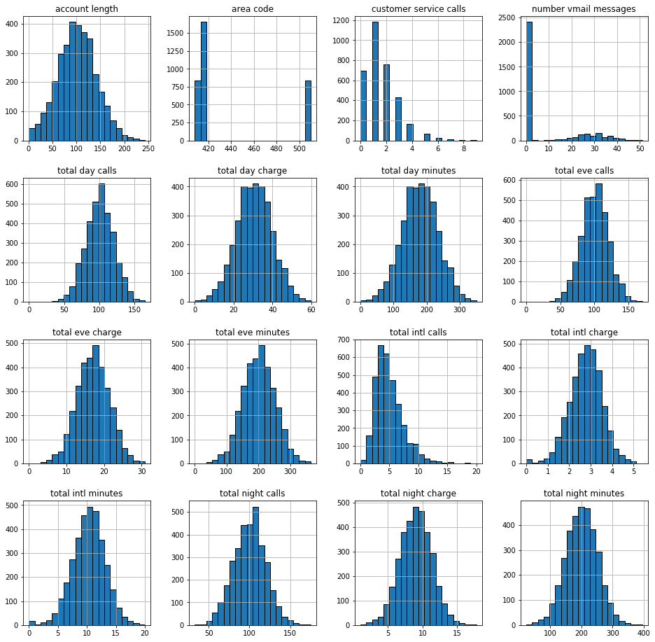

```python
# Split the data into features and target label
churn_data = tele['churn']
features_data = tele.drop('churn', axis = 1)
#features_log_transformed = pd.DataFrame(data = features_data)
hists = features_data.hist(figsize=(16, 16), bins=20,edgecolor='black')
# Visualize skewed continuous features of original data
#vs.distribution(tele)
```

[output not shown]

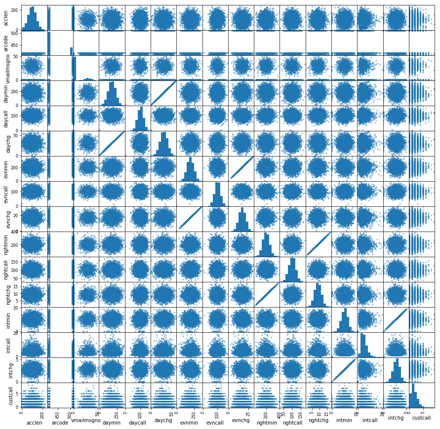

```python
features_data.columns=['state','acclen','arcode','phno','intl plan','vc plan','vmailmsgno','daymin','daycall','daychg','evnmin','evncall','evnchg','nghtmin',
                    'nghtcall','nghtchg','intmin','intcall','intchg','custcall']
pd.plotting.scatter_matrix(features_data,figsize=(15,15))
```

```python
drp = tele[['state','area code','phone number','international plan','voice mail plan','churn']]
X= tele.drop(drp,1)
y= tele.churn
X_train, X_test, y_train, y_test = train_test_split(X, y,test_size=0.25)
```

```python
X.describe()
```

|  | account length | number vmail messages | total day minutes | total day calls | total day charge | total eve minutes | total eve calls | total eve charge | total night minutes | total night calls | total night charge | total intl minutes | total intl calls | total intl charge | customer service calls |
| --- | --- | --- | --- | --- | --- | --- | --- | --- | --- | --- | --- | --- | --- | --- | --- |
| count | 3333.000000 | 3333.000000 | 3333.000000 | 3333.000000 | 3333.000000 | 3333.000000 | 3333.000000 | 3333.000000 | 3333.000000 | 3333.000000 | 3333.000000 | 3333.000000 | 3333.000000 | 3333.000000 | 3333.000000 |
| mean | 101.064806 | 8.099010 | 179.775098 | 100.435644 | 30.562307 | 200.980348 | 100.114311 | 17.083540 | 200.872037 | 100.107711 | 9.039325 | 10.237294 | 4.479448 | 2.764581 | 1.562856 |
| std | 39.822106 | 13.688365 | 54.467389 | 20.069084 | 9.259435 | 50.713844 | 19.922625 | 4.310668 | 50.573847 | 19.568609 | 2.275873 | 2.791840 | 2.461214 | 0.753773 | 1.315491 |
| min | 1.000000 | 0.000000 | 0.000000 | 0.000000 | 0.000000 | 0.000000 | 0.000000 | 0.000000 | 23.200000 | 33.000000 | 1.040000 | 0.000000 | 0.000000 | 0.000000 | 0.000000 |
| 25% | 74.000000 | 0.000000 | 143.700000 | 87.000000 | 24.430000 | 166.600000 | 87.000000 | 14.160000 | 167.000000 | 87.000000 | 7.520000 | 8.500000 | 3.000000 | 2.300000 | 1.000000 |
| 50% | 101.000000 | 0.000000 | 179.400000 | 101.000000 | 30.500000 | 201.400000 | 100.000000 | 17.120000 | 201.200000 | 100.000000 | 9.050000 | 10.300000 | 4.000000 | 2.780000 | 1.000000 |
| 75% | 127.000000 | 20.000000 | 216.400000 | 114.000000 | 36.790000 | 235.300000 | 114.000000 | 20.000000 | 235.300000 | 113.000000 | 10.590000 | 12.100000 | 6.000000 | 3.270000 | 2.000000 |
| max | 243.000000 | 51.000000 | 350.800000 | 165.000000 | 59.640000 | 363.700000 | 170.000000 | 30.910000 | 395.000000 | 175.000000 | 17.770000 | 20.000000 | 20.000000 | 5.400000 | 9.000000 |

```python
#churn_data = tele['churn']
#features_data = tele.drop('churn', axis = 1)
features_log_transformed = pd.DataFrame(data = X)
```

```python
# Import sklearn.preprocessing.StandardScaler
from sklearn.preprocessing import MinMaxScaler

# Initialize a scaler, then apply it to the features
scaler = MinMaxScaler() # default=(0, 1)
numerical = ['account length', 'total day minutes','total day calls','total eve minutes','total eve calls','total night minutes','total night calls','customer service calls','total intl charge','total intl calls','total intl minutes','total night charge','total eve charge','total day charge','number vmail messages']

features_log_minmax_transform = pd.DataFrame(data = features_log_transformed)
features_log_minmax_transform[numerical] = scaler.fit_transform(features_log_transformed[numerical])

# Show an example of a record with scaling applied
display(features_log_minmax_transform.head(n = 5))
#features_log_minmax_transform.describe()
```

|  | account length | number vmail messages | total day minutes | total day calls | total day charge | total eve minutes | total eve calls | total eve charge | total night minutes | total night calls | total night charge | total intl minutes | total intl calls | total intl charge | customer service calls |
| --- | --- | --- | --- | --- | --- | --- | --- | --- | --- | --- | --- | --- | --- | --- | --- |
| 0 | 0.524793 | 0.490196 | 0.755701 | 0.666667 | 0.755701 | 0.542755 | 0.582353 | 0.542866 | 0.595750 | 0.408451 | 0.595935 | 0.500 | 0.15 | 0.500000 | 0.111111 |
| 1 | 0.438017 | 0.509804 | 0.460661 | 0.745455 | 0.460597 | 0.537531 | 0.605882 | 0.537690 | 0.621840 | 0.492958 | 0.622236 | 0.685 | 0.15 | 0.685185 | 0.111111 |
| 2 | 0.561983 | 0.000000 | 0.693843 | 0.690909 | 0.693830 | 0.333242 | 0.647059 | 0.333225 | 0.374933 | 0.500000 | 0.375374 | 0.610 | 0.25 | 0.609259 | 0.000000 |
| 3 | 0.342975 | 0.000000 | 0.853478 | 0.430303 | 0.853454 | 0.170195 | 0.517647 | 0.170171 | 0.467187 | 0.394366 | 0.467424 | 0.330 | 0.35 | 0.329630 | 0.222222 |
| 4 | 0.305785 | 0.000000 | 0.475200 | 0.684848 | 0.475184 | 0.407754 | 0.717647 | 0.407959 | 0.440290 | 0.619718 | 0.440526 | 0.505 | 0.15 | 0.505556 | 0.333333 |

```python
#TODO: One-hot encode the 'features_log_minmax_transform' data using pandas.get_dummies()
#features_final = pd.get_dummies(data=features_log_minmax_transform, columns=['international plan', 'voice mail plan','state'])

# TODO: Encode the 'income_raw' data to numerical values
churn_data = pd.get_dummies(data=y)


# Print the number of features after one-hot encoding
encoded = list(churn_data.columns)
print("{} total features after one-hot encoding.".format(len(encoded)))

# Uncomment the following line to see the encoded feature names
print(encoded)
display(churn_data.head(n = 5))
```

```
2 total features after one-hot encoding.
[False, True]
```

|  | False | True |
| --- | --- | --- |
| 0 | 1 | 0 |
| 1 | 1 | 0 |
| 2 | 1 | 0 |
| 3 | 1 | 0 |
| 4 | 1 | 0 |

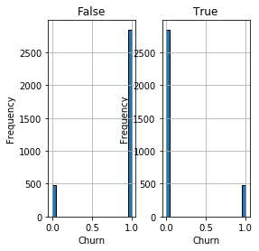

```python
ax = churn_data.hist(figsize=(4,4), bins=20,edgecolor='black')
for axe in ax.flatten():
    axe.set_xlabel("Churn")
    axe.set_ylabel("Frequency")
```

```python
n_churn = tele.groupby('churn')['phone number'].count()
print(n_churn[1])
print(tele.shape[0])

TP = np.sum(n_churn[1])
print(TP)
FP = tele.shape[0]-TP
print(FP)
TN = 0
FN = 0


# TODO: Calculate accu(racy, precision and recall
accuracy = (TP+TN)/tele.shape[0]
#print(accuracy)
recall = TP/(TP+FN)
print(recall)
precision = TP/(TP+FP)
print(precision)




# TODO: Calculate F-score using the formula above for beta = 0.5 and correct values for precision and recall.
fscore = (1+0.5**2)*((recall*precision)/(0.5**2*precision+recall))
print(fscore)

# Print the results
print("Naive Predictor: [F-score: {:.4f}]".format(fscore))
```

```
483
3333
483
2850
1.0
0.14491449144914492
0.17480998914223672
Naive Predictor: [F-score: 0.1748]
```

### Implementation - Creating a Training and Predicting Pipeline

To properly evaluate the performance of each model you've chosen, it's important that you create a training and predicting pipeline that allows you to quickly and effectively train models using various sizes of training data and perform predictions on the testing data. Your implementation here will be used in the following section. In the code block below, you will need to implement the following:

- Import `fbeta_score` and `accuracy_score` from [`sklearn.metrics`](http://scikit-learn.org/stable/modules/classes.html#sklearn-metrics-metrics).
- Fit the learner to the sampled training data and record the training time.
- Perform predictions on the test data `X_test`, and also on the training `X_train`.
  - Record the total prediction time.
- Calculate the F-score for both the training subset and testing set.
  - Make sure that you set the `beta` parameter!

### Supervised Learning Models

**The following supervised learning models are currently available in** [`scikit-learn`](http://scikit-learn.org/stable/supervised_learning.html) **that you may choose from:**

- Decision Trees
- Ensemble Methods (Bagging, AdaBoost, Random Forest, Gradient Boosting)
- Logistic Regression
- Linear Regression

Linear regression is great when the relationship to between covariates and response variable is known to be linear (duh). This is good as it shifts focus from statistical modeling and to data analysis and preprocessing. It is great for learning to play with data without worrying about the intricate details of the model.

A clear disadvantage is that Linear Regression over simplifies many real world problems. More often than not, covariates and response variables don’t exhibit a linear relationship. Hence fitting a regression line using OLS will give us a line with a high train RSS.

In summary, Linear Regression is great for learning about the data analysis process. However, it isn’t recommended for most practical applications because it oversimplifies real world problems

**Adaboost** is a Boosting type Ensemble Learning Method. In the industry, boosting algorithms have been used for the binary classification problem of face detection where the algorithm has to identify wheter a portion of an image is a face or background (ref: https://en.wikipedia.org/wiki/Boosting_(machine_learning)). One of the main strenghts of Adaboost is that it is a fast algorithm, agnostic to the classifier and less prone to overfitting. During the iterative training, it continuously gives more weight to missclassified labels to allow the classifier to focus on the harder cases which increases the overall model's performance. On the other hand, noisy data and outliers in the data can negatively impact the performance so data pre processing is important. Furthermore, if a complex model is used as the base classifier, this can lead to overfitting to the training data. In my opinion, this model is a good candidate for the problem as our dataset is large yet clean. Therefore we will be able to perform multiple quick trainining iterations to maximize our overall accuracy on the unseen testing data.

```python
from sklearn.metrics import recall_score
from sklearn.metrics import fbeta_score

results_logreg = {}

time_logreg = {}


logreg = LogisticRegression()
start = time()
logreg.fit(X_train, y_train)
end = time()
time_logreg['train_time'] = end-start

start = time()
predictions_test = logreg.predict(X_test)
predictions_train = logreg.predict(X_train)
end = time()
time_logreg['pred_time'] = end-start
#results_logreg['acc_train'] = accuracy_score(y_train[:300],predictions_train)
results_logreg['f_train'] = fbeta_score(y_train,predictions_train,beta=0.5)
#results_logreg['acc_test'] = accuracy_score(y_test,predictions_test)
results_logreg['f_test'] = fbeta_score(y_test,predictions_test,beta=0.5)

#print ("Logistic Regression: [Train Time : {:.4f},Predict Time : {:.4f}, Accuracy Train: {:.4f},F train: {:.4f},Acc Test: {:.4f},F Test: {:.4f}]".format(time_logreg['train_time'],time_logreg['pred_time'],results_logreg['acc_train'],results_logreg['f_train'],results_logreg['acc_test'],results_logreg['f_test']))

#print('Logistic regression  f score =',round(metrics.accuracy_score(y_test, predictions_test),2))
print('Logistic regression  f train score =',results_logreg['f_train'])
print('Logistic regression  f test score =',results_logreg['f_test'])
print('Logistic regression  prediction timing =',time_logreg['pred_time'])
print('Logistic regression  training =',time_logreg['train_time'])
```

```
Logistic regression  f train score = 0.26800670016750416
Logistic regression  f test score = 0.0684931506849315
Logistic regression  prediction timing = 0.0
Logistic regression  training = 0.03129172325134277
```

```python
scores = cross_val_score(logreg, X, y, cv=5, scoring='f1')
print('Logistic regression of each partition\n',scores)
print('Mean score of all the scores after cross validation =',round(scores.mean(),2))
results_logreg['mean_score'] =  round(scores.mean(),2)
```

```
Logistic regression of each partition
 [0.0776699  0.11650485 0.         0.09708738 0.09433962]
Mean score of all the scores after cross validation = 0.08
```

```
Text(33,0.5,'Actual')
```

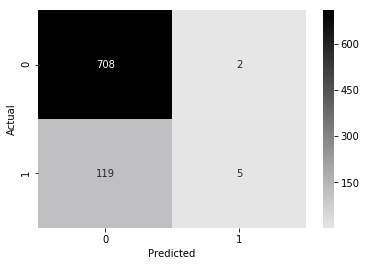

```python
conf = (metrics.confusion_matrix(y_test, predictions_test))
cmap = sns.cubehelix_palette(50, hue=0.05, rot=0, light=0.9, dark=0, as_cmap=True)
sns.heatmap(conf,cmap = cmap,xticklabels=['0','1'],yticklabels=['0','1'],annot=True, fmt="d",)
plt.xlabel('Predicted')
plt.ylabel('Actual')
```

```python
#results = {}
#results[logreg] = {}
#results[logreg][0] = {}

#results_logreg = {}
#results_logreg['train_time'] = end-start
#results_logreg['acc_test'] = accuracy_score(y_test,predictions_test)
#results_logreg['f_test'] = fbeta_score(y_test,predictions_test,beta=0.5)
```

```python
FP = conf[1][0]
FN = conf[0][1]
TP = conf[0][0]
TN = conf[1][1]
print('False Positive ',FP)
print('False Negative ',FN)
print('True Positive ',TP)
print('True Negative ',TN)
# Sensitivity, hit rate, recall, or true positive rate
TPR = TP/(TP+FN)
print('\nTrue Positive Rate :',round(TPR,2))
# Specificity or true negative rate
TNR = TN/(TN+FP)
print('\nTrue Negative Rate :',round(TNR,2))
# Precision or positive predictive value
PPV = TP/(TP+FP)
print('\nPositive Predictive Value :',round(PPV,2))
# Negative predictive value
NPV = TN/(TN+FN)
print('\nNegative Predictive Value :',round(NPV,2))
# Fall out or false positive rate
FPR = FP/(FP+TN)
print('\nFalse Positive Rate :',round(FPR,2))
# False negative rate
FNR = FN/(TP+FN)
print('\nFalse Negative Rate :',round(FNR,2))
# False discovery rate
FDR = FP/(TP+FP)
print('\nFalse Discovery Rate :',round(FDR,2))

# Overall accuracy
#ACC = (TP+TN)/(TP+FP+FN+TN)
#print('\nOverall accuracy :',round(ACC,2))
```

```
False Positive  119
False Negative  2
True Positive  708
True Negative  5

True Positive Rate : 1.0

True Negative Rate : 0.04

Positive Predictive Value : 0.86

Negative Predictive Value : 0.71

False Positive Rate : 0.96

False Negative Rate : 0.0

False Discovery Rate : 0.14
```

```python
results_rf = {}
timing_rf  = {}
rf_clf = RandomForestClassifier(n_estimators=120, criterion='entropy')
start = time()
rf_clf.fit(X_train, y_train)
end = time()
timing_rf['train_time'] = end-start

start = time()
predictions_test = rf_clf.predict(X_test)
predictions_train = rf_clf.predict(X_train)
end = time()

timing_rf['pred_time'] = end-start
#results_rf['acc_train'] = accuracy_score(y_train[:300],predictions_train)
results_rf['f_train'] = fbeta_score(y_train,predictions_train,beta=0.5)
#results_rf['acc_test'] = accuracy_score(y_test,predictions_test)
results_rf['f_test'] = fbeta_score(y_test,predictions_test,beta=0.5)


print('Random Forest Classifier f train score =',results_rf['f_train'])
print('Random Forest Classifier  f test score =',results_rf['f_test'])
print('Random Forest Classifier training time =',timing_rf['train_time'])
print('Random Forest Classifier  predict =',timing_rf['pred_time'])
#print ("Random Forest: [Train Time : {:.4f},Predict Time : {:.4f}, Accuracy Train: {:.4f},F train: {:.4f},Acc Test: {:.4f},F Test: {:.4f}]".format(timing_rf['train_time'],timing_rf['pred_time'],results_rf['acc_train'],results_rf['f_train'],results_rf['acc_test'],results_rf['f_test']))

#rf_pred_test = rf_clf.predict(X_test)
#print('Accuracy of Random forest :',round(metrics.accuracy_score(y_test, predictions_test),2))
```

```
Random Forest Classifier f train score = 1.0
Random Forest Classifier  f test score = 0.7650273224043715
Random Forest Classifier training time = 0.677161455154419
Random Forest Classifier  predict = 0.05343890190124512
```

```python
rf_scores = cross_val_score(rf_clf, X, y, cv=5, scoring='f1')
print('Cross Validation scores using random forest \n',rf_scores)
print('Mean of Cross Validation scores',round(rf_scores.mean(),2))
results_rf['Mean_Score'] = round(rf_scores.mean(),2)
```

```
Cross Validation scores using random forest
 [0.64968153 0.66666667 0.68918919 0.64335664 0.73076923]
Mean of Cross Validation scores 0.68
```

```
Text(33,0.5,'Actual')
```

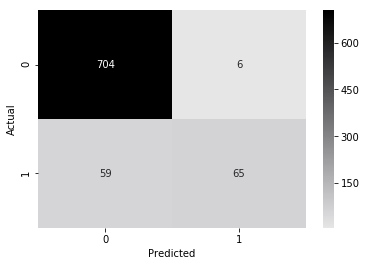

```python
rf_conf = (metrics.confusion_matrix(y_test, predictions_test))
cmap = sns.cubehelix_palette(50, hue=0.05, rot=0, light=0.9, dark=0, as_cmap=True)
sns.heatmap(rf_conf,cmap = cmap,xticklabels=['0','1'],yticklabels=['0','1'],annot=True, fmt="d",)
plt.xlabel('Predicted')
plt.ylabel('Actual')
```

```python
FP = rf_conf[1][0]
FN = rf_conf[0][1]
TP = rf_conf[0][0]
TN = rf_conf[1][1]
print('False Positive ',FP)
print('False Negative ',FN)
print('True Positive ',TP)
print('True Negative ',TN)
# Sensitivity, hit rate, recall, or true positive rate
TPR = TP/(TP+FN)
print('\nTrue Positive Rate :',round(TPR,2))
# Specificity or true negative rate
TNR = TN/(TN+FP)
print('\nTrue Negative Rate :',round(TNR,2))
# Precision or positive predictive value
PPV = TP/(TP+FP)
print('\nPositive Predictive Value :',round(PPV,2))
# Negative predictive value
NPV = TN/(TN+FN)
print('\nNegative Predictive Value :',round(NPV,2))
# Fall out or false positive rate
FPR = FP/(FP+TN)
print('\nFalse Positive Rate :',round(FPR,2))
# False negative rate
FNR = FN/(TP+FN)
print('\nFalse Negative Rate :',round(FNR,2))
# False discovery rate
FDR = FP/(TP+FP)
print('\nFalse Discovery Rate :',round(FDR,2))

# Overall accuracy
#ACC = (TP+TN)/(TP+FP+FN+TN)
#print('\nOverall accuracy :',round(ACC,2))
```

```
False Positive  59
False Negative  6
True Positive  704
True Negative  65

True Positive Rate : 0.99

True Negative Rate : 0.52

Positive Predictive Value : 0.92

Negative Predictive Value : 0.92

False Positive Rate : 0.48

False Negative Rate : 0.01

False Discovery Rate : 0.08
```

```python
from sklearn.naive_bayes import GaussianNB
from sklearn.svm import SVC
from sklearn.ensemble import AdaBoostClassifier


gaussian = GaussianNB()
svc = SVC(random_state=0)
adaboost = AdaBoostClassifier(random_state=0)

results_adb = {}
timing_adb = {}

start = time()
adaboost.fit(X_train, y_train)
end  = time()

timing_adb['train_time'] = end-start

start = time()
predictions_test = adaboost.predict(X_test)
predictions_train = adaboost.predict(X_train)
end = time()

timing_adb['pred_time'] = end-start
#results_adb['acc_train'] = accuracy_score(y_train[:300],predictions_train)
results_adb['f_train'] = fbeta_score(y_train,predictions_train,beta=0.5)
#results_adb['acc_test'] = accuracy_score(y_test,predictions_test)
results_adb['f_test'] = fbeta_score(y_test,predictions_test,beta=0.5)

print('Adaboost Classifier f train score =',results_adb['f_train'])
print('Adaboost Classifier  f test score =',results_adb['f_test'])
print('Adaboost Classifier  prediction time =',timing_adb['pred_time'])
print('Adaboost Classifier  training time =',timing_adb['train_time'])

#adb_pred_test = adaboost.predict(X_test)
#print ("AdaBoost: [Train Time : {:.4f},Predict Time : {:.4f}, Accuracy Train: {:.4f},F train: {:.4f},Acc Test: {:.4f},F Test: {:.4f}]".format(timing_adb['train_time'],timing_adb['pred_time'],results_adb['acc_train'],results_adb['f_train'],results_adb['acc_test'],results_adb['f_test']))

#print('Accuracy of Adaboost :',round(metrics.accuracy_score(y_test, predictions_test),2))
```

```
Adaboost Classifier f train score = 0.579185520361991
Adaboost Classifier  f test score = 0.4748603351955307
Adaboost Classifier  prediction time = 0.015627145767211914
Adaboost Classifier  training time = 0.20013189315795898
```

```python
gaussian.fit(X_train, y_train)
gausn_pred_test = gaussian.predict(X_test)
print('Accuracy of Gaussian :',round(metrics.accuracy_score(y_test, gausn_pred_test),2))
```

```
Accuracy of Gaussian : 0.89
```

```python
svc.fit(X_train, y_train)
svc_pred_test = svc.predict(X_test)
print('Accuracy of Adaboost :',round(metrics.accuracy_score(y_test, svc_pred_test),2))
```

[output not shown]

```python
adb_scores = cross_val_score(adaboost, X, y, cv=5, scoring='f1')
print('Cross Validation scores using adaboost \n',adb_scores)
print('Mean of Cross Validation scores',round(adb_scores.mean(),2))
results_adb['Mean_Score'] = round(adb_scores.mean(),2)
```

```
Cross Validation scores using adaboost
 [0.41610738 0.38095238 0.4109589  0.36734694 0.44444444]
Mean of Cross Validation scores 0.4
```

```
Text(33,0.5,'Actual')
```

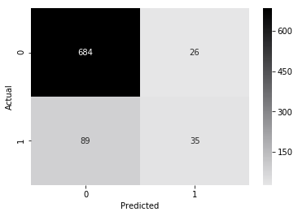

```python
adb_conf = (metrics.confusion_matrix(y_test, predictions_test))
cmap = sns.cubehelix_palette(50, hue=0.05, rot=0, light=0.9, dark=0, as_cmap=True)
sns.heatmap(adb_conf,cmap = cmap,xticklabels=['0','1'],yticklabels=['0','1'],annot=True, fmt="d",)
plt.xlabel('Predicted')
plt.ylabel('Actual')
```

```python
FP = adb_conf[1][0]
FN = adb_conf[0][1]
TP = adb_conf[0][0]
TN = adb_conf[1][1]
print('False Positive ',FP)
print('False Negative ',FN)
print('True Positive ',TP)
print('True Negative ',TN)
# Sensitivity, hit rate, recall, or true positive rate
TPR = TP/(TP+FN)
print('\nTrue Positive Rate :',round(TPR,2))
# Specificity or true negative rate
TNR = TN/(TN+FP)
print('\nTrue Negative Rate :',round(TNR,2))
# Precision or positive predictive value
PPV = TP/(TP+FP)
print('\nPositive Predictive Value :',round(PPV,2))
# Negative predictive value
NPV = TN/(TN+FN)
print('\nNegative Predictive Value :',round(NPV,2))
# Fall out or false positive rate
FPR = FP/(FP+TN)
print('\nFalse Positive Rate :',round(FPR,2))
# False negative rate
FNR = FN/(TP+FN)
print('\nFalse Negative Rate :',round(FNR,2))
# False discovery rate
FDR = FP/(TP+FP)
print('\nFalse Discovery Rate :',round(FDR,2))

# Overall accuracy
#ACC = (TP+TN)/(TP+FP+FN+TN)
#print('\nOverall accuracy :',round(ACC,2))
```

```
False Positive  89
False Negative  26
True Positive  684
True Negative  35

True Positive Rate : 0.96

True Negative Rate : 0.28

Positive Predictive Value : 0.88

Negative Predictive Value : 0.57

False Positive Rate : 0.72

False Negative Rate : 0.04

False Discovery Rate : 0.12
```

#### Results:

[output not shown]

```
3
```

[figure not shown]

[figure not shown]

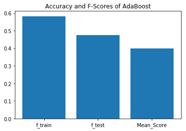

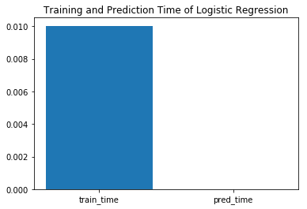

[figure not shown]

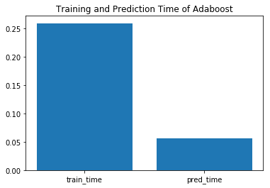

```python
#results = {}
#results[logreg.__class__.__name__] = {}

#results[logreg.__class__.__name__][0] = results_logreg
#results[rf_clf.__class__.__name__] = {}
#results[rf_clf.__class__.__name__][0] = results_rf
#results[adaboost.__class__.__name__] = {}
#results[adaboost.__class__.__name__][0] = results_adb

#from IPython.display import display # Allows the use of display() for DataFrames

# Import supplementary visualization code visuals.py
#import visuals as vs
#vs.evaluate(results, accuracy, fscore)

import matplotlib.pyplot as plt
import numpy as np

import matplotlib.pyplot as plt

D = {u'Label1':26, u'Label2': 17, u'Label3':30}
print(len(results_logreg))

plt.bar(range(len(results_logreg)), list(results_logreg.values()), align='center')
plt.xticks(range(len(results_logreg)), list(results_logreg.keys()))
plt.title("Accuracy and F-Scores of Logistic Regression")
# # for python 2.x:
# plt.bar(range(len(D)), D.values(), align='center')  # python 2.x
# plt.xticks(range(len(D)), D.keys())  # in python 2.x

plt.show()

plt.bar(range(len(results_rf)), list(results_rf.values()), align='center')
plt.xticks(range(len(results_rf)), list(results_rf.keys()))
# # for python 2.x:
# plt.bar(range(len(D)), D.values(), align='center')  # python 2.x
# plt.xticks(range(len(D)), D.keys())  # in python 2.x
plt.title("Accuracy and F-Scores of Random Forest")
plt.show()

plt.bar(range(len(results_adb)), list(results_adb.values()), align='center')
plt.xticks(range(len(results_adb)), list(results_adb.keys()))
plt.title("Accuracy and F-Scores of AdaBoost")
# # for python 2.x:
# plt.bar(range(len(D)), D.values(), align='center')  # python 2.x
# plt.xticks(range(len(D)), D.keys())  # in python 2.x

plt.show()




plt.bar(range(len(time_logreg)), list(time_logreg.values()), align='center')
plt.xticks(range(len(time_logreg)), list(time_logreg.keys()))
# # for python 2.x:
# plt.bar(range(len(D)), D.values(), align='center')  # python 2.x
# plt.xticks(range(len(D)), D.keys())  # in python 2.x
plt.title("Training and Prediction Time of Logistic Regression")
plt.show()

plt.bar(range(len(timing_rf)), list(timing_rf.values()), align='center')
plt.xticks(range(len(timing_rf)), list(timing_rf.keys()))
plt.title("Training and Prediction Time of Random Forest")
# # for python 2.x:
# plt.bar(range(len(D)), D.values(), align='center')  # python 2.x
# plt.xticks(range(len(D)), D.keys())  # in python 2.x

plt.show()

plt.bar(range(len(timing_adb)), list(timing_adb.values()), align='center')
plt.xticks(range(len(timing_adb)), list(timing_adb.keys()))
plt.title("Training and Prediction Time of Adaboost")
# # for python 2.x:
# plt.bar(range(len(D)), D.values(), align='center')  # python 2.x
# plt.xticks(range(len(D)), D.keys())  # in python 2.x

plt.show()
```

```python
# TODO: Import 'GridSearchCV', 'make_scorer', and any other necessary libraries
from sklearn.model_selection import GridSearchCV
from sklearn.metrics import fbeta_score, make_scorer
from sklearn.ensemble import AdaBoostClassifier
# TODO: Import 'GridSearchCV', 'make_scorer', and any other necessary libraries
from sklearn.grid_search import GridSearchCV
from sklearn.metrics import make_scorer

print("Start")
# TODO: Initialize the classifier
clf = RandomForestClassifier(random_state=0)

# TODO: Create the parameters list you wish to tune
parameters = {'n_estimators': [10,100,500,1000,2000],
              'criterion': ['gini', 'entropy']}

# TODO: Make an fbeta_score scoring object
scorer = make_scorer(fbeta_score, beta=0.5)

# TODO: Perform grid search on the classifier using 'scorer' as the scoring method
grid_obj = GridSearchCV(clf,parameters,scoring=scorer)

# TODO: Fit the grid search object to the training data and find the optimal parameters
grid_fit = grid_obj.fit(X_train,y_train)

# Get the estimator
best_clf = grid_fit.best_estimator_

# Make predictions using the unoptimized and model
predictions = (clf.fit(X_train, y_train)).predict(X_test)
best_predictions = best_clf.predict(X_test)

# Report the before-and-afterscores
#print ("Unoptimized model\n------")
#print ("F-score on testing data: {:.4f}").format(fbeta_score(y_test, predictions, beta = 0.5))
#print ("\nOptimized Model\n------")
#print ("Final F-score on the testing data: {:.4f}").format(fbeta_score(y_test, best_predictions, beta = 0.5))
# Report the before-and-afterscores
print("Unoptimized model\n------")
#print("Accuracy score on testing data: {:.4f}".format(accuracy_score(y_test, predictions)))
#print("F-score on testing data: {:.4f}").format(fbeta_score(y_test, predictions, beta = 0.5)))
print(fbeta_score(y_test, predictions, beta = 0.5))
print("\nOptimized Model\n------")
#print("Final accuracy score on the testing data: {:.4f}".format(accuracy_score(y_test['>50K'], best_predictions)))
#print("Final F-score on the testing data: {:.4f}").format(fbeta_score(y_test, best_predictions, beta = 0.5)))
print(fbeta_score(y_test, best_predictions, beta = 0.5))
```

```
Start
Unoptimized model
------
0.689655172413793

Optimized Model
------
0.7954545454545454
```

```python
start = time()
best_clf.predict(X_test)
end = time()

print("clf took " + str(end-start))

start = time()
best_clf.predict(X_test)
end = time()

print("best_clf took " + str(end-start))
```

```
clf took 0.09978079795837402
best_clf took 0.0681002140045166
```

### Supervised Learning Models

**The following supervised learning models are currently available in** [`scikit-learn`](http://scikit-learn.org/stable/supervised_learning.html) **that you may choose from:**

- Decision Trees
- Ensemble Methods (Bagging, AdaBoost, Random Forest, Gradient Boosting)
- Logistic Regression

```python
clf
```

```
RandomForestClassifier(bootstrap=True, class_weight=None, criterion='gini',
            max_depth=None, max_features='auto', max_leaf_nodes=None,
            min_impurity_decrease=0.0, min_impurity_split=None,
            min_samples_leaf=1, min_samples_split=2,
            min_weight_fraction_leaf=0.0, n_estimators=10, n_jobs=1,
            oob_score=False, random_state=0, verbose=0, warm_start=False)
```

### Question 2 - Model Application

```python
best_clf
```

```
RandomForestClassifier(bootstrap=True, class_weight=None, criterion='entropy',
            max_depth=None, max_features='auto', max_leaf_nodes=None,
            min_impurity_decrease=0.0, min_impurity_split=None,
            min_samples_leaf=1, min_samples_split=2,
            min_weight_fraction_leaf=0.0, n_estimators=500, n_jobs=1,
            oob_score=False, random_state=0, verbose=0, warm_start=False)
```

#### Results:

[output not shown]

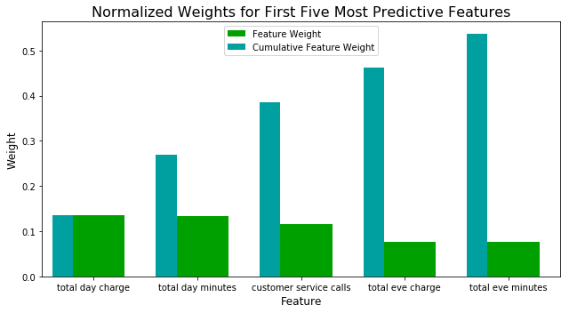

```python
# TODO: Import a supervised learning model that has 'feature_importances_'
# TODO: Train the supervised model on the training set

# Since, I already trained a RandomForest with our dataset and it has feature_importances_,
# I will re use the best_clf
model = best_clf

# TODO: Extract the feature importances
importances = model.feature_importances_

# Plot
vs.feature_plot(importances, X_train, y_train)
```

```python
# Import functionality for cloning a model
from sklearn.base import clone

# Reduce the feature space
X_train_reduced = X_train[X_train.columns.values[(np.argsort(importances)[::-1])[:5]]]
X_test_reduced = X_test[X_test.columns.values[(np.argsort(importances)[::-1])[:5]]]

# Train on the "best" model found from grid search earlier
clf = (clone(best_clf)).fit(X_train_reduced, y_train)

# Make new predictions
reduced_predictions = clf.predict(X_test_reduced)

# Report scores from the final model using both versions of data
print ("Final Model trained on full data\n------")
#print "Accuracy on testing data: {:.4f}".format(accuracy_score(y_test, best_predictions))
print("The prediction on full data",fbeta_score(y_test, best_predictions, beta = 0.5))
print("The prediction on reduced features",fbeta_score(y_test, reduced_predictions, beta = 0.5))
#print "F-score on testing data: {:.4f}".format(fbeta_score(y_test, best_predictions, beta = 0.5))
#print "\nFinal Model trained on reduced data\n------"
#print "Accuracy on testing data: {:.4f}".format(accuracy_score(y_test, reduced_predictions))
#print "F-score on testing data: {:.4f}".format(fbeta_score(y_test, reduced_predictions, beta = 0.5))
```

```
Final Model trained on full data
------
The prediction on full data 0.7954545454545454
The prediction on reduced features 0.7193396226415094
```